# Feature_Selection

Roselynn

1/23/2021

# Importing the Dataset and Loading the Appropriate Packages.

I first loaded the tidyverse package and then imported my dataset

```r
library(tidyverse)
library(caret)
dataset <- read.csv("http://bit.ly/CarreFourDataset")
```

I then used the glimpse() function to preview my dataset

```r
glimpse(dataset)
```

```
## Rows: 1,000
## Columns: 16
## $ Invoice.ID              <chr> "750-67-8428", "226-31-3081", "631-41-3108"...
## $ Branch                  <chr> "A", "C", "A", "A", "A", "C", "A", "C", "A"...
## $ Customer.type           <chr> "Member", "Normal", "Normal", "Member", "No...
## $ Gender                  <chr> "Female", "Female", "Male", "Male", "Male",...
## $ Product.line            <chr> "Health and beauty", "Electronic accessorie...
## $ Unit.price              <dbl> 74.69, 15.28, 46.33, 58.22, 86.31, 85.39, 6...
## $ Quantity                <int> 7, 5, 7, 8, 7, 7, 6, 10, 2, 3, 4, 4, 5, 10,...
## $ Tax                     <dbl> 26.1415, 3.8200, 16.2155, 23.2880, 30.2085,...
## $ Date                    <chr> "1/5/2019", "3/8/2019", "3/3/2019", "1/27/2...
## $ Time                    <chr> "13:08", "10:29", "13:23", "20:33", "10:37"...
## $ Payment                 <chr> "Ewallet", "Cash", "Credit card", "Ewallet"...
## $ cogs                    <dbl> 522.83, 76.40, 324.31, 465.76, 604.17, 597....
## $ gross.margin.percentage <dbl> 4.761905, 4.761905, 4.761905, 4.761905, 4.7...
## $ gross.income            <dbl> 26.1415, 3.8200, 16.2155, 23.2880, 30.2085,...
## $ Rating                  <dbl> 9.1, 9.6, 7.4, 8.4, 5.3, 4.1, 5.8, 8.0, 7.2...
## $ Total                   <dbl> 548.9715, 80.2200, 340.5255, 489.0480, 634....
```

The dataset had 16 columns , 8 of type character and 8 numeric columns.

# 2.Data Cleaning

I then used the summary() function to get the summary statistics of the columns in my dataset.

```r
summary(dataset)
```

```
##   Invoice.ID           Branch          Customer.type         Gender
##  Length:1000        Length:1000        Length:1000        Length:1000
##  Class :character   Class :character   Class :character   Class :character
##  Mode  :character   Mode  :character   Mode  :character   Mode  :character
##
##
##
##  Product.line         Unit.price       Quantity          Tax
##  Length:1000        Min.   :10.08   Min.   : 1.00   Min.   : 0.5085
##  Class :character   1st Qu.:32.88   1st Qu.: 3.00   1st Qu.: 5.9249
##  Mode  :character   Median :55.23   Median : 5.00   Median :12.0880
##                     Mean   :55.67   Mean   : 5.51   Mean   :15.3794
##                     3rd Qu.:77.94   3rd Qu.: 8.00   3rd Qu.:22.4453
##                     Max.   :99.96   Max.   :10.00   Max.   :49.6500
##      Date               Time             Payment               cogs
##  Length:1000        Length:1000        Length:1000        Min.   : 10.17
##  Class :character   Class :character   Class :character   1st Qu.:118.50
##  Mode  :character   Mode  :character   Mode  :character   Median :241.76
##                                                           Mean   :307.59
##                                                           3rd Qu.:448.90
##                                                           Max.   :993.00
##  gross.margin.percentage  gross.income         Rating           Total
##  Min.   :4.762           Min.   : 0.5085   Min.   : 4.000   Min.   :  10.68
##  1st Qu.:4.762           1st Qu.: 5.9249   1st Qu.: 5.500   1st Qu.: 124.42
##  Median :4.762           Median :12.0880   Median : 7.000   Median : 253.85
##  Mean   :4.762           Mean   :15.3794   Mean   : 6.973   Mean   : 322.97
##  3rd Qu.:4.762           3rd Qu.:22.4453   3rd Qu.: 8.500   3rd Qu.: 471.35
##  Max.   :4.762           Max.   :49.6500   Max.   :10.000   Max.   :1042.65
```

### 2.1.Checking for Null Values

I checked for any null entries , the dataset had none

```r
sum(is.na(dataset))
```

```
## [1] 0
```

```r
sum(duplicated(dataset))
```

```
## [1] 0
```

# 3.Feature Selection

## 3.1.Filter Method

The used the correlation coefficient to filter out the highly correlated features from the dataset.

```r
dataset <- select(dataset , -1,-2,-3,-4,-5,-9,-10,-11,-16,-13)
head(dataset)
```

```
##   Unit.price Quantity     Tax   cogs gross.income Rating
## 1      74.69        7 26.1415 522.83      26.1415    9.1
## 2      15.28        5  3.8200  76.40       3.8200    9.6
## 3      46.33        7 16.2155 324.31      16.2155    7.4
## 4      58.22        8 23.2880 465.76      23.2880    8.4
## 5      86.31        7 30.2085 604.17      30.2085    5.3
## 6      85.39        7 29.8865 597.73      29.8865    4.1
```

I selected the continuous variables within my dataset , however I did not select the Total , as this was the target variable in the dataset. I also dropped the Gross.margin.percentage as the columnn had a constant value and was therefore redundant.

I used the Pearson’s Correlation Coefficient and set a cutoff of 0.75 , features with a correlation coefficient greater that 0.75 were then excluded from the model.

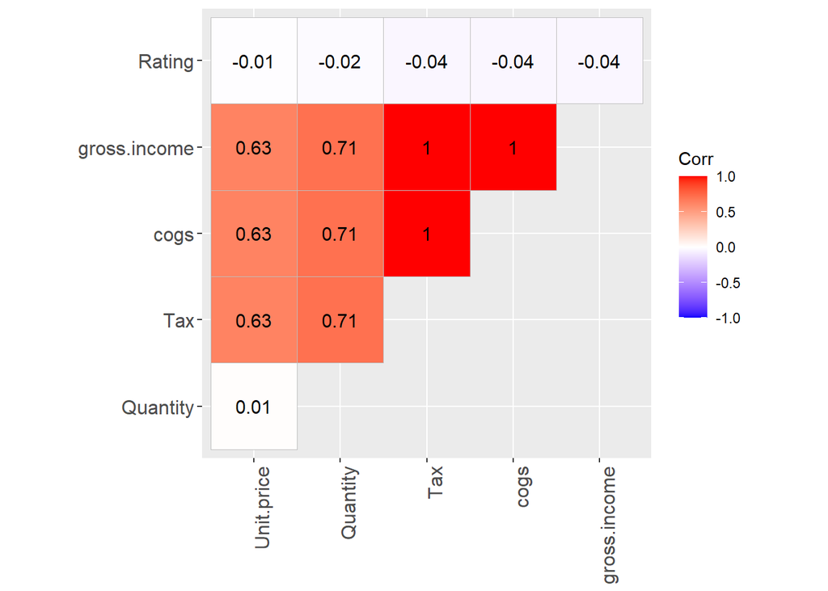

```r
# Calculating the correlation matrix

correlationMatrix <- cor(dataset)


library(ggcorrplot)
library(corrplot)
ggcorrplot(correlationMatrix ,hc.order=F,lab=T, type = 'upper' , tl.srt=90 , ggtheme = ggplot2::theme_gray, )
```

```r
# Find attributes that are highly correlated

highlyCorrelated <- findCorrelation(correlationMatrix, cutoff=0.75)

# Highly correlated attributes

highlyCorrelated
```

```
## [1] 3 4
```

```r
names(dataset[,highlyCorrelated])
```

```
## [1] "Tax"  "cogs"
```

The highly correlated features in this dataset were the Cogs and Tax features with a correlation coefficient of 1.

I then dropped these from the dataset.

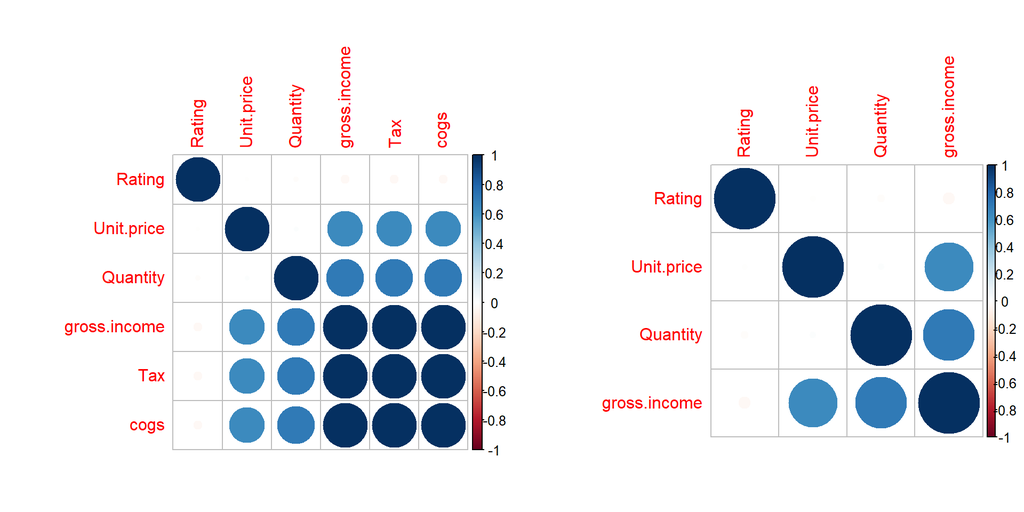

```r
# We can remove the variables with a higher correlation
# and comparing the results graphically as shown below
# ---
#
# Removing Redundant Features
# ---
#
Dataset2<-dataset[-highlyCorrelated]

# Performing our graphical comparison
# ---
#
par(mfrow = c(1, 2))
corrplot(correlationMatrix, order = "hclust")
corrplot(cor(Dataset2), order = "hclust")
```

After removing the highly correlated features from my dataset I was left with :

- Rating
- Unit Price
- Quantity
- Gross Income As my features.

## 3.2.Wrapper Method

I also attempted to use the Wrapper method to carry out feature selection.

```r
Dataset <- read.csv("http://bit.ly/CarreFourDataset")
Dataset <- select(Dataset , -1,-2,-3,-4,-5,-9,-10,-11,-13,-16)
head(Dataset)
```

```
##   Unit.price Quantity     Tax   cogs gross.income Rating
## 1      74.69        7 26.1415 522.83      26.1415    9.1
## 2      15.28        5  3.8200  76.40       3.8200    9.6
## 3      46.33        7 16.2155 324.31      16.2155    7.4
## 4      58.22        8 23.2880 465.76      23.2880    8.4
## 5      86.31        7 30.2085 604.17      30.2085    5.3
## 6      85.39        7 29.8865 597.73      29.8865    4.1
```

I wanted to select the best features to use in building my model from the features listed above.

I used the clustvarsel package to carry out the feature selection.

```r
# Sequential forward greedy search (default)
# ---
#
library(clustvarsel)
library(mclust)
out = clustvarsel(Dataset)
out
```

```
## ------------------------------------------------------
## Variable selection for Gaussian model-based clustering
## Stepwise (forward/backward) greedy search
## ------------------------------------------------------
##
##  Variable proposed Type of step   BICclust Model G   BICdiff Decision
##           Quantity          Add  -4308.761     E 9  687.4466 Accepted
##               cogs          Add -16306.851   VEV 9 1083.0132 Accepted
##         Unit.price          Add -21393.079   EVV 7 2812.3733 Accepted
##         Unit.price       Remove -16306.851   VEV 9 2812.3733 Rejected
##             Rating          Add -25510.859   EVV 7 -184.0917 Rejected
##         Unit.price       Remove -16306.851   VEV 9 2812.3733 Rejected
##
## Selected subset: Quantity, cogs, Unit.price
```

I then used the selected subset from the features above.

The Selected subset: Quantity, cogs, Unit.price

```r
Subset1 = Dataset[,out$subset]
mod = Mclust(Subset1 , G = 1:3)
summary(mod)
```

```
## ----------------------------------------------------
## Gaussian finite mixture model fitted by EM algorithm
## ----------------------------------------------------
##
## Mclust VVV (ellipsoidal, varying volume, shape, and orientation) model with 3
## components:
##
##  log-likelihood    n df       BIC       ICL
##       -11651.57 1000 29 -23503.46 -23601.14
##
## Clustering table:
##   1   2   3
## 309 376 315
```

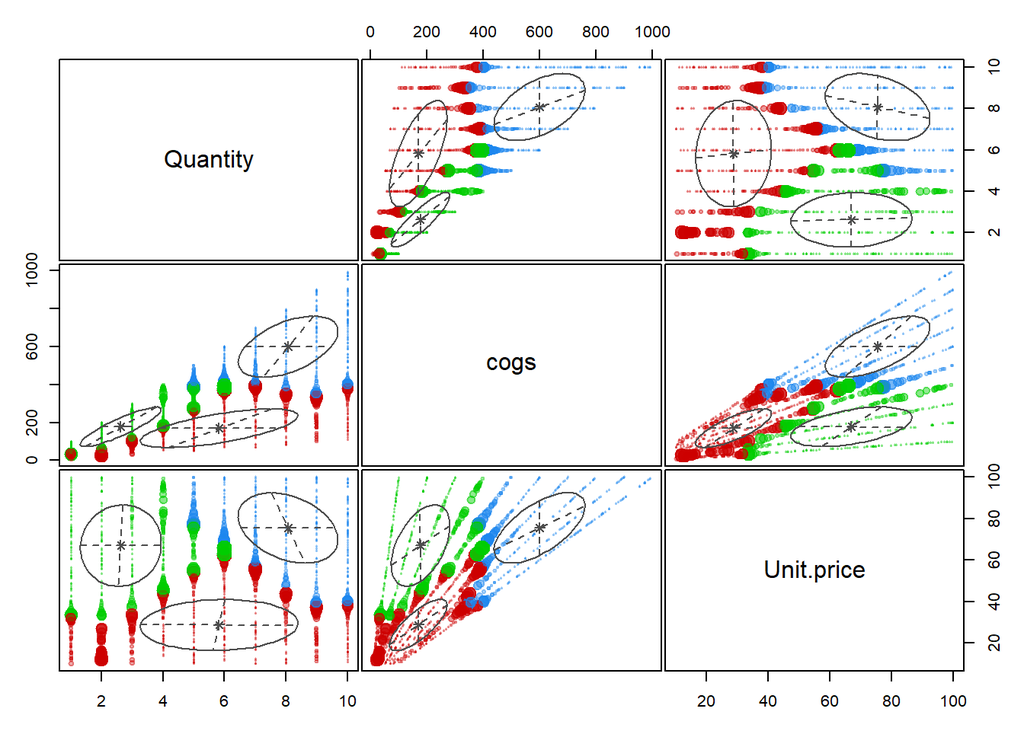

```r
plot(mod,c("uncertainty"))
```

# Summary

After carrying out both methods , the filter method selected four features , the ones that were not highly correlated while the wrapper method selected a subset of three features from the dataset.